# Project

Mohini Yadav and Erin Nell

**Important Links:**

[Link to GitHub Repository](https://momotheduckyy.github.io/)

[Link to the dataset and additional information](https://www.kaggle.com/datasets/abdulszz/spotify-most-streamed-songs?resource=download)

```python
from google.colab import drive
drive.mount('/content/drive')
```

```python
!ls "/content/drive/MyDrive/Colab Notebooks"
```

```
'Colab Notebooks'	   'Copy of Lab04.ipynb'  'Copy of Lab10.ipynb'   spotifymoststreamed.csv
'Copy2 of Lab08.ipynb'	   'Copy of Lab05.ipynb'  'Copy of Lab11.ipynb'   test_file.txt
'Copy of Lab01.ipynb'	   'Copy of Lab06.ipynb'  'Copy of Lab12.ipynb'   Untitled
'Copy of Lab02.ipynb'	   'Copy of Lab07.ipynb'   Lab03.ipynb
'Copy of Lab03.ipynb'	   'Copy of Lab08.ipynb'   Project.html
'Copy of Lab04 (1).ipynb'  'Copy of Lab09.ipynb'   Project.ipynb
```

```python
!mv "/content/drive/MyDrive/Colab Notebooks/Project" "/content/drive/MyDrive/Colab Notebooks/Project.ipynb"
```

```
mv: cannot stat '/content/drive/MyDrive/Colab Notebooks/Project': No such file or directory
```

```python
%%shell
jupyter nbconvert --to html "/content/drive/MyDrive/Colab Notebooks/Project.ipynb"
```

```
[NbConvertApp] Converting notebook /content/drive/MyDrive/Colab Notebooks/Project.ipynb to html
[NbConvertApp] WARNING | Alternative text is missing on 6 image(s).
[NbConvertApp] Writing 900386 bytes to /content/drive/MyDrive/Colab Notebooks/Project.html
```

# Project Overview

For this project, the group is Mohini Yadav and Erin Nell.

We will be conducting an analysis on the Spotify streaming data for 2023 and 2024. The dataset, Spotify Songs Streamed 2023, includes various features such as song titles, artists, and release years, and streaming counts across different platforms for the year of 2023. The Spotify Songs Streamed 2024 dataset includes the same variables, but with some added information about a songs performance on social media platforms, such as TikTok or YouTube.

We believe that working with Spotify streaming data presents a unique opportunity to further understand market insights and song performance. Analyzing streaming data helps us understand current music trends, and evolving listener preferences. This insight can be valuable for artists, producers, and marketers in the music industry. With song performance, understanding which songs perform best on streaming platforms can inform marketing strategies and decisions on which songs to promote.

Some possible questions for further exploration are: Can we use the Spotify Stream count across the years to understand what songs remain the most streamed songs over the years. Moreover, does social media like TikTok play a roll in how much a song is streamed? Do characteristics such as acousticness, energy, or explicitness affect stream count?

# Collaboration Plan

The team plans to meet once a week to work on and discuss the project and determine next steps. We will also communicate frequently over text messages to stay updated with our progress on the project and, if necessary, we will meet over facetime or schedule additional in-person meetings. We also have a Google Doc which has a list of to-do items and general notes about the project. Lastly, we have a shared Github repository where we may store and update our code.

# Extraction, Transform, and Load

We first begin by loading a dataset from Kaggle which contains the Spotify streaming data for 2023. We tidy the data by removing unwanted columns, such as the the cover_url link which we would not be using in our analysis, ensuring the data is the correct type, and replacing cells incomplete data with NaN values or deleting the row depending on the context.

```python
import pandas as pd
import numpy as np
import matplotlib.pyplot as plt

path = '/content/drive/My Drive/spotify/spotifymoststreamed.csv'
df = pd.read_csv(path)
df.head()
```

|  | track_name | artist(s)_name | artist_count | released_year | released_month | released_day | in_spotify_playlists | in_spotify_charts | streams | in_apple_playlists | ... | key | mode | danceability_% | valence_% | energy_% | acousticness_% | instrumentalness_% | liveness_% | speechiness_% | cover_url |
| --- | --- | --- | --- | --- | --- | --- | --- | --- | --- | --- | --- | --- | --- | --- | --- | --- | --- | --- | --- | --- | --- |
| 0 | Seven (feat. Latto) (Explicit Ver.) | Latto, Jung Kook | 2 | 2023 | 7 | 14 | 553 | 147 | 141381703 | 43 | ... | B | Major | 80 | 89 | 83 | 31 | 0 | 8 | 4 | Not Found |
| 1 | LALA | Myke Towers | 1 | 2023 | 3 | 23 | 1474 | 48 | 133716286 | 48 | ... | C# | Major | 71 | 61 | 74 | 7 | 0 | 10 | 4 | https://i.scdn.co/image/ab67616d0000b2730656d5... |
| 2 | vampire | Olivia Rodrigo | 1 | 2023 | 6 | 30 | 1397 | 113 | 140003974 | 94 | ... | F | Major | 51 | 32 | 53 | 17 | 0 | 31 | 6 | https://i.scdn.co/image/ab67616d0000b273e85259... |
| 3 | Cruel Summer | Taylor Swift | 1 | 2019 | 8 | 23 | 7858 | 100 | 800840817 | 116 | ... | A | Major | 55 | 58 | 72 | 11 | 0 | 11 | 15 | https://i.scdn.co/image/ab67616d0000b273e787cf... |
| 4 | WHERE SHE GOES | Bad Bunny | 1 | 2023 | 5 | 18 | 3133 | 50 | 303236322 | 84 | ... | A | Minor | 65 | 23 | 80 | 14 | 63 | 11 | 6 | https://i.scdn.co/image/ab67616d0000b273ab5c9c... |

5 rows × 25 columns

First, we are removing columns not valuable to our analysis. We are removing any column which refers to the number of playlists since we do not have the scale. i.e. how many playlists on the platform, so we can not compare this number across platforms.

```python
# drop cover_url since it is not useful to our analysis
df = df.drop(['cover_url', 'in_spotify_playlists', 'in_apple_playlists', 'in_deezer_playlists', 'in_apple_charts', 'in_deezer_charts', 'in_shazam_charts'], axis=1)
```

Ensure that the data has correct types. We want to make sure that each data type correctly reflects the type of value in that variable.

```python
# Identify rows with non-numeric 'streams' values
non_numeric_streams = df[~df['streams'].str.isnumeric()]

# Remove row
df = df.drop(574)

# fixing data types by converting from int64 to object since we want to view dates as categorical variables
df['released_year'] = df['released_year'].astype('object')
df['released_month'] = df['released_month'].astype('object')
df['released_day'] = df['released_day'].astype('object')

# convert "streams" to an integer (currently prints as object)
df['streams'] = df['streams'].astype('int64')

display(df.dtypes)
```

|  | 0 |
| --- | --- |
| track_name | object |
| artist(s)_name | object |
| artist_count | int64 |
| released_year | object |
| released_month | object |
| released_day | object |
| in_spotify_charts | int64 |
| streams | int64 |
| bpm | int64 |
| key | object |
| mode | object |
| danceability_% | int64 |
| valence_% | int64 |
| energy_% | int64 |
| acousticness_% | int64 |
| instrumentalness_% | int64 |
| liveness_% | int64 |
| speechiness_% | int64 |

**dtype:** object

Looking at this initial code, there are lots of values with missing data specifically in the key and in_shazam_charts columns, so we are replacing those values with NaN. We will not be removing the columns entirely because the row still provides important data about streaming count which could be analyzed seperately.

```python
df = df.replace({'': np.nan, None: np.nan})
df.head()
```

|  | track_name | artist(s)_name | artist_count | released_year | released_month | released_day | in_spotify_charts | streams | bpm | key | mode | danceability_% | valence_% | energy_% | acousticness_% | instrumentalness_% | liveness_% | speechiness_% |
| --- | --- | --- | --- | --- | --- | --- | --- | --- | --- | --- | --- | --- | --- | --- | --- | --- | --- | --- |
| 0 | Seven (feat. Latto) (Explicit Ver.) | Latto, Jung Kook | 2 | 2023 | 7 | 14 | 147 | 141381703 | 125 | B | Major | 80 | 89 | 83 | 31 | 0 | 8 | 4 |
| 1 | LALA | Myke Towers | 1 | 2023 | 3 | 23 | 48 | 133716286 | 92 | C# | Major | 71 | 61 | 74 | 7 | 0 | 10 | 4 |
| 2 | vampire | Olivia Rodrigo | 1 | 2023 | 6 | 30 | 113 | 140003974 | 138 | F | Major | 51 | 32 | 53 | 17 | 0 | 31 | 6 |
| 3 | Cruel Summer | Taylor Swift | 1 | 2019 | 8 | 23 | 100 | 800840817 | 170 | A | Major | 55 | 58 | 72 | 11 | 0 | 11 | 15 |
| 4 | WHERE SHE GOES | Bad Bunny | 1 | 2023 | 5 | 18 | 50 | 303236322 | 144 | A | Minor | 65 | 23 | 80 | 14 | 63 | 11 | 6 |

**Joining an Additional Dataset for Spotify Streams 2024**

Now, we are adding a second dataset which looks at the songs with the most streams in 2024 on spotify. We are going to analyze this dataset, which offers additional insights such as whether a song is explicit and its stream/view numbers on other platfors such as TikTok or YouTube.

With our joined data, we want to find out if there any songs that have remained popular over between 2023 and 2024, and what are there characteristics?

```python
# uploading our new dataset
path3 = '/content/drive/My Drive/spotify/moststreamedspotify2024.csv'
df2024 = pd.read_csv(path3, encoding='ISO-8859-1')
df2024.head()
```

|  | Track | Album Name | Artist | Release Date | ISRC | All Time Rank | Track Score | Spotify Streams | Spotify Playlist Count | Spotify Playlist Reach | ... | SiriusXM Spins | Deezer Playlist Count | Deezer Playlist Reach | Amazon Playlist Count | Pandora Streams | Pandora Track Stations | Soundcloud Streams | Shazam Counts | TIDAL Popularity | Explicit Track |
| --- | --- | --- | --- | --- | --- | --- | --- | --- | --- | --- | --- | --- | --- | --- | --- | --- | --- | --- | --- | --- | --- |
| 0 | MILLION DOLLAR BABY | Million Dollar Baby - Single | Tommy Richman | 4/26/2024 | QM24S2402528 | 1 | 725.4 | 390,470,936 | 30,716 | 196,631,588 | ... | 684 | 62.0 | 17,598,718 | 114.0 | 18,004,655 | 22,931 | 4,818,457 | 2,669,262 | NaN | 0 |
| 1 | Not Like Us | Not Like Us | Kendrick Lamar | 5/4/2024 | USUG12400910 | 2 | 545.9 | 323,703,884 | 28,113 | 174,597,137 | ... | 3 | 67.0 | 10,422,430 | 111.0 | 7,780,028 | 28,444 | 6,623,075 | 1,118,279 | NaN | 1 |
| 2 | i like the way you kiss me | I like the way you kiss me | Artemas | 3/19/2024 | QZJ842400387 | 3 | 538.4 | 601,309,283 | 54,331 | 211,607,669 | ... | 536 | 136.0 | 36,321,847 | 172.0 | 5,022,621 | 5,639 | 7,208,651 | 5,285,340 | NaN | 0 |
| 3 | Flowers | Flowers - Single | Miley Cyrus | 1/12/2023 | USSM12209777 | 4 | 444.9 | 2,031,280,633 | 269,802 | 136,569,078 | ... | 2,182 | 264.0 | 24,684,248 | 210.0 | 190,260,277 | 203,384 | NaN | 11,822,942 | NaN | 0 |
| 4 | Houdini | Houdini | Eminem | 5/31/2024 | USUG12403398 | 5 | 423.3 | 107,034,922 | 7,223 | 151,469,874 | ... | 1 | 82.0 | 17,660,624 | 105.0 | 4,493,884 | 7,006 | 207,179 | 457,017 | NaN | 1 |

5 rows × 29 columns

First, we want to cleanup this dataset. There are a few things we wish to do, such as replacing null values with NaN, although at a glance it looks like there are none. We will also drop columns we will not use and remove commas in the number values so that it matches with the 2023 dataset.

```python
df_tidy2024 = df2024

# replacing empty entries, if any, with NaN
df_tidy2024 = df_tidy2024.replace({'': np.nan, None: np.nan})

# dropping columns not useful to our analysis
df_tidy2024 = df_tidy2024.drop(['Spotify Playlist Count', 'Spotify Playlist Reach', 'SiriusXM Spins',
                                'Deezer Playlist Reach', 'Amazon Playlist Count', 'Pandora Streams',
                                'Pandora Track Stations', 'Soundcloud Streams', 'Shazam Counts', 'TIDAL Popularity',
                                 'Apple Music Playlist Count', 'Deezer Playlist Count',
                                'Apple Music Playlist Count', 'YouTube Playlist Reach', 'ISRC'], axis=1)

# remove commas in numbers to match our first dataset
columns_to_clean = [
    'Spotify Streams', 'YouTube Views', 'YouTube Likes',
    'TikTok Posts', 'TikTok Likes', 'TikTok Views',  'AirPlay Spins']
for column in columns_to_clean:
    df_tidy2024[column] = df_tidy2024[column].str.replace(',', '', regex=False)


df_tidy2024.head()
```

|  | Track | Album Name | Artist | Release Date | All Time Rank | Track Score | Spotify Streams | Spotify Popularity | YouTube Views | YouTube Likes | TikTok Posts | TikTok Likes | TikTok Views | AirPlay Spins | Explicit Track |
| --- | --- | --- | --- | --- | --- | --- | --- | --- | --- | --- | --- | --- | --- | --- | --- |
| 0 | MILLION DOLLAR BABY | Million Dollar Baby - Single | Tommy Richman | 4/26/2024 | 1 | 725.4 | 390470936 | 92.0 | 84274754 | 1713126 | 5767700 | 651565900 | 5332281936 | 40975 | 0 |
| 1 | Not Like Us | Not Like Us | Kendrick Lamar | 5/4/2024 | 2 | 545.9 | 323703884 | 92.0 | 116347040 | 3486739 | 674700 | 35223547 | 208339025 | 40778 | 1 |
| 2 | i like the way you kiss me | I like the way you kiss me | Artemas | 3/19/2024 | 3 | 538.4 | 601309283 | 92.0 | 122599116 | 2228730 | 3025400 | 275154237 | 3369120610 | 74333 | 0 |
| 3 | Flowers | Flowers - Single | Miley Cyrus | 1/12/2023 | 4 | 444.9 | 2031280633 | 85.0 | 1096100899 | 10629796 | 7189811 | 1078757968 | 14603725994 | 1474799 | 0 |
| 4 | Houdini | Houdini | Eminem | 5/31/2024 | 5 | 423.3 | 107034922 | 88.0 | 77373957 | 3670188 | 16400 | NaN | NaN | 12185 | 1 |

Next, we want to ensure that the data is of the correct type, categorical or numerical, for when we start analyzing it:

```python
# fixing data types by converting from int64 to object since we want to view dates as categorical variables
  # drop any data that doesnt have a number for spotify streams since thats what we are focusing on
df_tidy2024 = df_tidy2024.dropna(subset=['Spotify Streams'])
df_tidy2024['Spotify Streams'] = df_tidy2024['Spotify Streams'].astype('int64')

# replace the Nan values with 0 since this is just additional information
df_tidy2024['YouTube Views'] = df_tidy2024['YouTube Views'].fillna(0).astype('int64')
df_tidy2024['YouTube Likes'] = df_tidy2024['YouTube Likes'].fillna(0).astype('int64')
df_tidy2024['TikTok Posts'] = df_tidy2024['TikTok Posts'].fillna(0).astype('int64')
df_tidy2024['TikTok Likes'] = df_tidy2024['TikTok Likes'].fillna(0).astype('int64')
df_tidy2024['TikTok Views'] = df_tidy2024['TikTok Views'].fillna(0).astype('int64')
df_tidy2024['AirPlay Spins'] = df_tidy2024['AirPlay Spins'].fillna(0).astype('int64')

# fix the type for the explicit track column to boolean
df_tidy2024['Explicit Track'] = df_tidy2024['Explicit Track'].replace({0: False, 1: True}).astype(bool)

#display(df_tidy2024.dtypes)
```

Now, we are going to join the datsets by the song and artist and tidy the data so we can draw conclusions during our analysis:

```python
df2023 = df
df2024 = df_tidy2024

# standardizing the column names for when we merge
df2023.rename(columns={'track_name': 'song', 'artist(s)_name': 'artist'}, inplace=True)
df2024.rename(columns={'Track': 'song', 'Artist': 'artist'}, inplace=True)

# merging the the dataframes based on an inner join so we only get songs that appear both in 2023 and 2024
merged_dfs = pd.merge(df2023, df2024, on=['song', 'artist'], how='inner')

# dropping columns we dont need
merged_dfs = merged_dfs.drop(columns=['Release Date', 'Album Name', 'All Time Rank', 'in_spotify_charts', 'Spotify Popularity', 'Track Score'])

# renaming based on year
merged_dfs.rename(columns={'streams': 'streams_2023', 'Spotify Streams': 'streams_2024'}, inplace=True)

# add new column which shows the difference between the stream count by year
merged_dfs['stream_change'] = merged_dfs['streams_2024'] - merged_dfs['streams_2023']

# remove songs with a negative stream change since that is impossible and means the stream count was entered in incorrectly
merged_dfs = merged_dfs[merged_dfs['stream_change'] >= 0]

# creating a new column order so (spotify) streams are next to each other
new_column_order = ['song', 'artist', 'artist_count', 'released_year', 'released_month',
       'released_day', 'streams_2023', 'streams_2024', 'stream_change','bpm', 'key', 'mode', 'danceability_%', 'valence_%',
        'energy_%', 'acousticness_%', 'instrumentalness_%', 'liveness_%', 'speechiness_%', 'YouTube Views',
        'YouTube Likes', 'TikTok Posts', 'TikTok Likes', 'TikTok Views', 'AirPlay Spins', 'Explicit Track']
merged_dfs = merged_dfs[new_column_order]

# if there are duplicates, so keep first occurence of the duplicate
merged_dfs = merged_dfs[~merged_dfs['song'].duplicated(keep='first')]

merged_dfs.head()
```

|  | song | artist | artist_count | released_year | released_month | released_day | streams_2023 | streams_2024 | stream_change | bpm | ... | instrumentalness_% | liveness_% | speechiness_% | YouTube Views | YouTube Likes | TikTok Posts | TikTok Likes | TikTok Views | AirPlay Spins | Explicit Track |
| --- | --- | --- | --- | --- | --- | --- | --- | --- | --- | --- | --- | --- | --- | --- | --- | --- | --- | --- | --- | --- | --- |
| 0 | LALA | Myke Towers | 1 | 2023 | 3 | 23 | 133716286 | 925655569 | 791939283 | 92 | ... | 0 | 10 | 4 | 934302031 | 4294166 | 11054500 | 521725116 | 7499234052 | 92231 | True |
| 1 | vampire | Olivia Rodrigo | 1 | 2023 | 6 | 30 | 140003974 | 998964097 | 858960123 | 138 | ... | 0 | 31 | 6 | 113450524 | 2108657 | 394640 | 152624014 | 1448207880 | 161513 | True |
| 3 | Cruel Summer | Taylor Swift | 1 | 2019 | 8 | 23 | 800840817 | 2188247133 | 1387406316 | 170 | ... | 0 | 11 | 15 | 342388433 | 2291619 | 3233521 | 465904062 | 4967025679 | 913464 | False |
| 4 | WHERE SHE GOES | Bad Bunny | 1 | 2023 | 5 | 18 | 303236322 | 717849037 | 414612715 | 144 | ... | 63 | 11 | 6 | 217687654 | 1929598 | 308670 | 85402638 | 808518802 | 57673 | True |
| 6 | Columbia | Quevedo | 1 | 2023 | 7 | 7 | 58149378 | 721002940 | 662853562 | 100 | ... | 0 | 11 | 4 | 266411536 | 1343262 | 372100 | 71411756 | 752868970 | 51158 | False |

5 rows × 26 columns

Making sure that the data has the correct types again:

```python
# tidy data to be in the correct type for when we conduct an analysis
merged_dfs['released_year'] = merged_dfs['released_year'].astype('object')
merged_dfs['released_month'] = merged_dfs['released_month'].astype('object')
merged_dfs['released_day'] = merged_dfs['released_day'].astype('object')


display(merged_dfs.dtypes)
```

|  | 0 |
| --- | --- |
| song | object |
| artist | object |
| artist_count | int64 |
| released_year | object |
| released_month | object |
| released_day | object |
| streams_2023 | int64 |
| streams_2024 | int64 |
| stream_change | int64 |
| bpm | int64 |
| key | object |
| mode | object |
| danceability_% | int64 |
| valence_% | int64 |
| energy_% | int64 |
| acousticness_% | int64 |
| instrumentalness_% | int64 |
| liveness_% | int64 |
| speechiness_% | int64 |
| YouTube Views | int64 |
| YouTube Likes | int64 |
| TikTok Posts | int64 |
| TikTok Likes | int64 |
| TikTok Views | int64 |
| AirPlay Spins | int64 |
| Explicit Track | bool |

**dtype:** object

# Exploratory Data Analysis

**Summary Statistics**

We will first start by finding the summary statistics for our joined dataset to get an overall sense of what our data is telling us:

```python
# Summary Statistics for our merged dataset
merged_dfs.describe()
```

|  | artist_count | streams_2023 | streams_2024 | stream_change | bpm | danceability_% | valence_% | energy_% | acousticness_% | instrumentalness_% | liveness_% | speechiness_% | YouTube Views | YouTube Likes | TikTok Posts | TikTok Likes | TikTok Views | AirPlay Spins |
| --- | --- | --- | --- | --- | --- | --- | --- | --- | --- | --- | --- | --- | --- | --- | --- | --- | --- | --- |
| count | 379.000000 | 3.790000e+02 | 3.790000e+02 | 3.790000e+02 | 379.000000 | 379.000000 | 379.000000 | 379.000000 | 379.000000 | 379.000000 | 379.000000 | 379.000000 | 3.790000e+02 | 3.790000e+02 | 3.790000e+02 | 3.790000e+02 | 3.790000e+02 | 3.790000e+02 |
| mean | 1.007916 | 6.485909e+08 | 8.848070e+08 | 2.362161e+08 | 124.683377 | 65.620053 | 50.092348 | 63.042216 | 26.939314 | 1.981530 | 17.493404 | 9.203166 | 4.423840e+08 | 4.309422e+06 | 9.977830e+05 | 2.198316e+08 | 2.134646e+09 | 1.415321e+05 |
| std | 0.088734 | 6.273042e+08 | 7.290242e+08 | 1.796835e+08 | 29.335498 | 14.573050 | 23.499058 | 16.649779 | 26.351190 | 9.893196 | 12.784201 | 8.869029 | 7.521749e+08 | 6.278891e+06 | 1.930345e+06 | 2.845556e+08 | 3.061796e+09 | 2.623042e+05 |
| min | 1.000000 | 1.478042e+07 | 8.980664e+07 | 1.230768e+07 | 65.000000 | 25.000000 | 4.000000 | 9.000000 | 0.000000 | 0.000000 | 3.000000 | 2.000000 | 0.000000e+00 | 0.000000e+00 | 0.000000e+00 | 0.000000e+00 | 0.000000e+00 | 0.000000e+00 |
| 25% | 1.000000 | 2.029495e+08 | 3.428159e+08 | 1.019014e+08 | 100.000000 | 56.000000 | 31.000000 | 52.000000 | 5.000000 | 0.000000 | 10.000000 | 4.000000 | 1.023755e+08 | 1.023160e+06 | 1.055925e+05 | 3.844008e+07 | 3.511801e+08 | 3.323500e+03 |
| 50% | 1.000000 | 3.875707e+08 | 5.995475e+08 | 1.912990e+08 | 123.000000 | 67.000000 | 49.000000 | 63.000000 | 16.000000 | 0.000000 | 12.000000 | 6.000000 | 2.028262e+08 | 2.369761e+06 | 3.819260e+05 | 1.067833e+08 | 1.027127e+09 | 2.260700e+04 |
| 75% | 1.000000 | 9.145238e+08 | 1.250718e+09 | 3.262491e+08 | 143.500000 | 76.500000 | 68.000000 | 77.000000 | 43.000000 | 0.000000 | 22.000000 | 10.000000 | 4.972057e+08 | 5.025188e+06 | 1.097248e+06 | 3.003077e+08 | 2.760785e+09 | 1.725810e+05 |
| max | 2.000000 | 3.703895e+09 | 4.281469e+09 | 1.387406e+09 | 206.000000 | 95.000000 | 97.000000 | 97.000000 | 97.000000 | 90.000000 | 83.000000 | 46.000000 | 8.013997e+09 | 6.231118e+07 | 1.889472e+07 | 1.889279e+09 | 2.224110e+10 | 1.777811e+06 |

Next, we wanted to look into some of the additional attributes included in this dataset, such as the percentage of the song that is acoustic. From the summary statistics below we can infer that songs with less acousticness are more likely to appear on this list of most streamed songs. This is evident from the average being about 27% acousticness and 75% of the data falling beneath an acoustic level of 43%. In contrast, energy has a average percentage of 63, with the third quartil being at 77%. Thus, songs with a relatively high energy level, at least higher than acousticness, are going to appear on this list.

```python
# combine acousticness_% with energy_%
combined_dfs = pd.concat([merged_dfs['acousticness_%'], merged_dfs['energy_%']], axis=1)

# Ggt descriptive statistics for both variables
described = combined_dfs.describe()
print(described)
```

```
       acousticness_%    energy_%
count      379.000000  379.000000
mean        26.939314   63.042216
std         26.351190   16.649779
min          0.000000    9.000000
25%          5.000000   52.000000
50%         16.000000   63.000000
75%         43.000000   77.000000
max         97.000000   97.000000
```

It will also be helpful to see what song was the most streamed in 2023, 2024, and which song has the most streams overall:

```python
# most streamed song in 2023
most_streamed_2023 = merged_dfs.loc[merged_dfs['streams_2023'].idxmax()]

# most streamed song in 2024
most_streamed_2024 = merged_dfs.loc[merged_dfs['streams_2024'].idxmax()]

# most streamed song overall (sum of 2023 and 2024 streams)
merged_dfs['total_streams'] = merged_dfs['streams_2023'] + merged_dfs['streams_2024']
most_streamed_overall = merged_dfs.loc[merged_dfs['total_streams'].idxmax()]

# display the results
print("Most Streamed Song in 2023:")
print(most_streamed_2023[['song', 'streams_2023']])

print("\nMost Streamed Song in 2024:")
print(most_streamed_2024[['song', 'streams_2024']])

print("\nMost Streamed Song Overall:")
print(most_streamed_overall[['song', 'total_streams']])
```

```
Most Streamed Song in 2023:
song            Blinding Lights
streams_2023         3703895074
Name: 33, dtype: object

Most Streamed Song in 2024:
song            Blinding Lights
streams_2024         4281468720
Name: 33, dtype: object

Most Streamed Song Overall:
song             Blinding Lights
total_streams         7985363794
Name: 33, dtype: object
```

Interestingly, this just so happens to be the same song for each statistic, Blinding Lights by The Weeknd. We can conclude that no song has been able to outshine Blinding Lights. However, lets look at the stream change.

```python
# find the stream change value for the song "Blinding Lights"
merged_dfs[merged_dfs['song'].str.lower() == 'blinding lights']['stream_change']
```

|  | stream_change |
| --- | --- |
| 33 | 577573646 |

**dtype:** int64

We can see that there was a growth of 577,573,646 streams between 2023 and 2024. Although a large number, looking at our bar chart analysis below, we can conclude that although incredibly popular, The Weeknd's Blinding Lights does not have the same growth as some of the other songs during these years. Further investigation can be done later on to understand what makes a strong have a high stream count versus a sustained high stream count.

**Bar Chart**

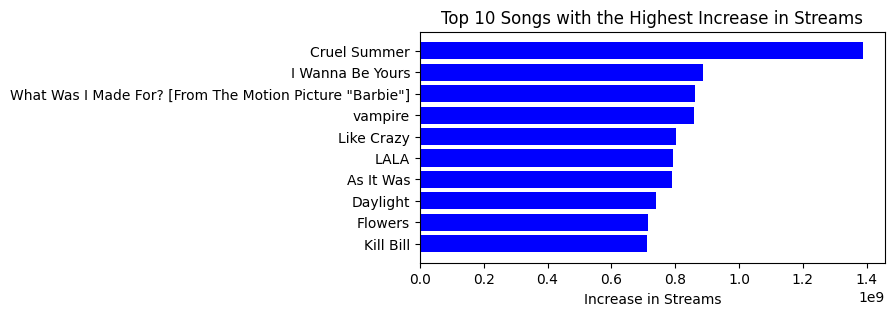

```python
# find the top 10 songs with the largest stream_change values
top_gainers = merged_dfs.nlargest(10, 'stream_change')

# plot bar graph
plt.figure(figsize=(6, 3))
plt.barh(top_gainers['song'], top_gainers['stream_change'], color='blue')
plt.xlabel('Increase in Streams')
plt.title('Top 10 Songs with the Highest Increase in Streams')
plt.gca().invert_yaxis()
plt.show()
```

Cruel Summer by Taylor Swift has the highest increase in streams by far. We can use use this information to understand what makes a song so popular.

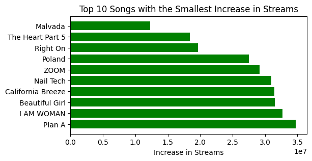

```python
# find the top 10 songs with the smallest stream_change values
top_losers = merged_dfs.nsmallest(10, 'stream_change')

# plot bar graph
plt.figure(figsize=(6, 3))
plt.barh(top_losers['song'], top_losers['stream_change'], color='green')
plt.xlabel('Increase in Streams')
plt.title('Top 10 Songs with the Smallest Increase in Streams')
plt.gca().invert_yaxis()
plt.show()
```

**Boxplot**

We can also create a boxplot to see if there is any correlation between a songs change in streams from 2023 to 2024 and if the track is explicit:

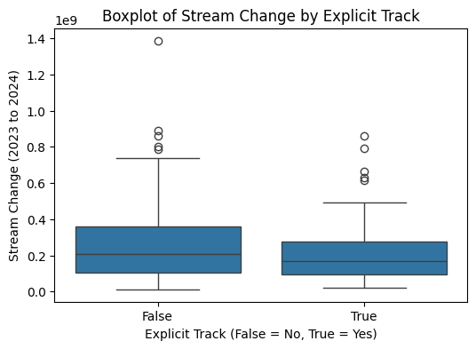

```python
import seaborn as sns

# plot a boxplot that measures the stream change to whether or not the track is explicit
plt.figure(figsize=(6, 4))
sns.boxplot(x='Explicit Track', y='stream_change', data=merged_dfs)
plt.title("Boxplot of Stream Change by Explicit Track")
plt.xlabel('Explicit Track (False = No, True = Yes)')
plt.ylabel('Stream Change (2023 to 2024)')
plt.show()
```

We can see that the average of non-explicit songs is a bit higher than that of explicit songs. Moreover, non-explicit songs also have a larger inter-quartile-range. However, this means that just because a song is explicit, is can perform just as well over time as songs without explicit lyrics as their means are similar and have outliers in a similar range. Despite this, a song with no explicit content is likely to perform better.

**Heat Map**

A heatmap is going to be a good way to quickly gauge the correlation between different variables. We can see on our map that there is a relatively strong correlation between YouTube Views, Youtube Likes, and Airplay Spins with the streams by year. This holds for when looking at the stream change variable (which shows which songs continued to have a lot of streams from 2023 and 2024), but interestingly the Airplay Spins has the highest correlation. This means that there is a correlation between how often a song is played on the radio and its total streams.

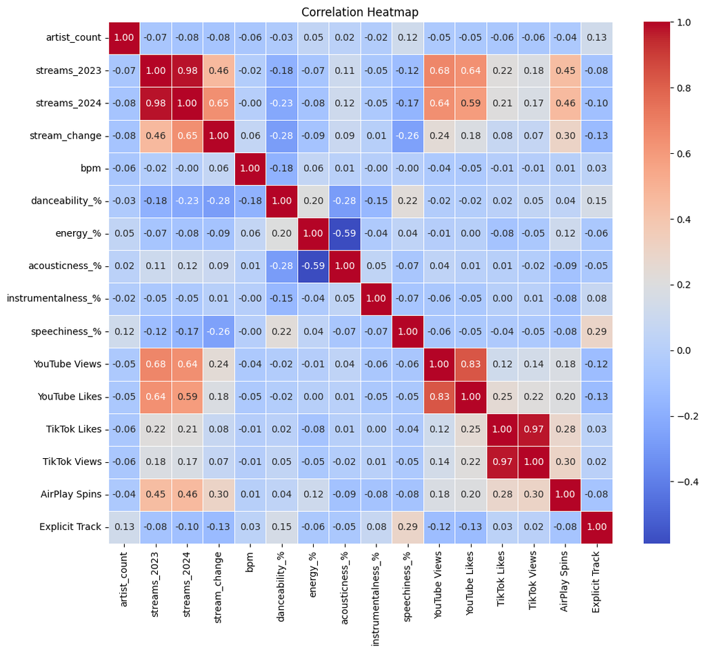

```python
# going to remove some of the extra columns we are unlikely to look at for a simpler looking heat map
merged_dfs_heat = merged_dfs.drop(columns=['liveness_%', 'TikTok Posts', 'total_streams', 'valence_%'])

columns_with_zeros = [
    'YouTube Views', 'YouTube Likes', 'TikTok Likes',  'TikTok Views', 'AirPlay Spins']
# Filter out rows where any of the specified columns are 0, meaning the data wasnt available
merged_dfs_heat = merged_dfs_heat[(merged_dfs_heat[columns_with_zeros] != 0).all(axis=1)]

# select only numerical columns
numerical_df = merged_dfs_heat.select_dtypes(include=['float64', 'int64', 'bool'])

# calculate the correlation matrix
correlation_matrix = numerical_df.corr()

# plot heatmap
plt.figure(figsize=(12, 10))
sns.heatmap(correlation_matrix, annot=True, cmap='coolwarm', fmt=".2f", linewidths=0.5)
plt.title('Correlation Heatmap')
plt.show()
```

```
The average TikTok Likes is: 224825348.62021858
```

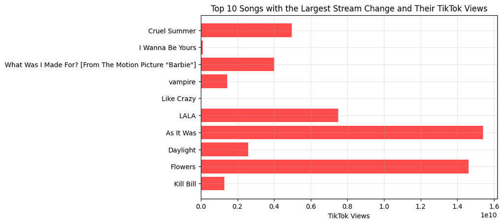

```python
average_tiktok_likes = merged_dfs_heat['TikTok Likes'].mean()
print(f"The average TikTok Likes is: {average_tiktok_likes}")

# Select the top 10 songs with the largest stream change
top_stream_change = merged_dfs.nlargest(10, 'stream_change')

# Plot the data
plt.figure(figsize=(8, 5))
plt.barh(top_stream_change['song'], top_stream_change['TikTok Views'], color='red', alpha=0.7)
plt.xlabel('TikTok Views')
plt.title('Top 10 Songs with the Largest Stream Change and Their TikTok Views')
plt.gca().invert_yaxis()  # Invert y-axis to show the highest value at the top
plt.grid(alpha=0.3)
plt.show()
```

**Scatter Plots**

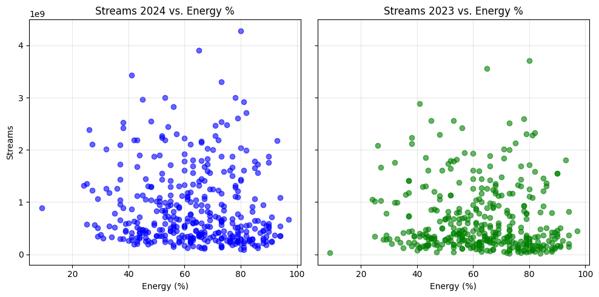

```python
# create subplots with two plots side by side
fig, axes = plt.subplots(1, 2, figsize=(10, 5), sharey=True)

# plot for streams in 2024
axes[0].scatter(merged_dfs['energy_%'], merged_dfs['streams_2024'], color='blue', alpha=0.6)
axes[0].set_title('Streams 2024 vs. Energy %')
axes[0].set_xlabel('Energy (%)')
axes[0].set_ylabel('Streams')
axes[0].grid(alpha=0.3)

# plot for streams in 2023
axes[1].scatter(merged_dfs['energy_%'], merged_dfs['streams_2023'], color='green', alpha=0.6)
axes[1].set_title('Streams 2023 vs. Energy %')
axes[1].set_xlabel('Energy (%)')
axes[1].grid(alpha=0.3)

# display the plots
plt.tight_layout()
plt.show()
```

**Histogram**

Next, to get a better sense of the data we made a histogram which shows the frequency that a certain month appears in the datatset of most streamed songs. This is relavent to our goal because it can help us identify trends to see if songs released in certain months are more likely to perform well. The histogram below could be considered multimodal, with multiple bumps histogram indicating a frequency of data around January, May, and December. Thus, if we were to make a conclusion from this graph, it could be said that songs released in these months are more likely to perform better in terms of meeting the list of Spotify Most Streamed Songs. Although this is not currently one of the characteristics of the data we are going to set our models on, it could potentially be used and otherwise provides an interesting insight on when music is released.

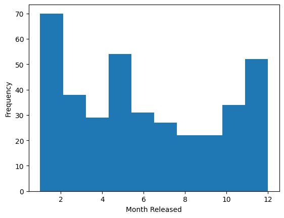

```python
# plot a histogram for released_month
merged_dfs['released_month'].plot.hist(bins = 10)

# plot label for x-axis
plt.xlabel('Month Released')
```

# Building Models

We are planning to build models to understand the impact of social media on streaming popularity and the effect of song characteristics on stream count:

**Model 1:**

Question: Does social media like TikTok and YouTube play a role in how much a song is streamed?

Approach: For this, we plan to use a **K-nearest neighbors (KNN) model**. KNN will analyze songs based on their social media activity and identify patterns. By comparing the social media activity of songs in the same cluster, we can find whether higher social media engagement is related to higher streaming counts or changes in streams.

Dependent Variable: the change in stream count from 2023 to 2024, stream_change

Independent Variables: TikTok metrics (TikTok Likes, TikTok Views) YouTube Likes and potentially AirPlay Spins.

**Model 2:**

Question: Do characteristics such as acousticness, energy, or explicitness affect stream count?

Approach: We plan to compare two **logistic regression models** to determine whether characteristics like acousticness_%, energy_%, and Explicit Track are significant predictors of a song achieving high stream counts. We will model the likelihood that a song has a high stream change based on these characteristics.

Dependent Variable: the stream count, either streams_2024 or streams_2023.

Independent variables: include song characteristics (acousticness_%, energy_%, Explicit Track).